# **Red Wines Exploration by Gourav Aich**

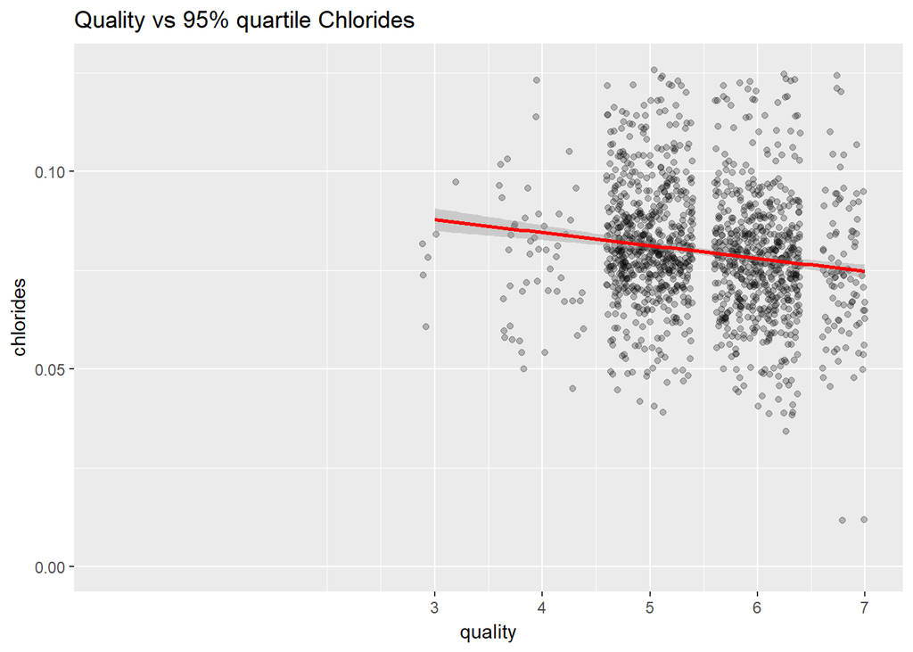

```
## # A tibble: 6 × 4
##   quality    cl_mean cl_median     n
##     <int>      <dbl>     <dbl> <int>
## 1       3 0.12250000    0.0905    10
## 2       4 0.09067925    0.0800    53
## 3       5 0.09273568    0.0810   681
## 4       6 0.08495611    0.0780   638
## 5       7 0.07658794    0.0730   199
## 6       8 0.06844444    0.0705    18
```

```
##
##  Pearson's product-moment correlation
##
## data:  quality and chlorides
## t = -5.1948, df = 1597, p-value = 2.313e-07
## alternative hypothesis: true correlation is not equal to 0
## 95 percent confidence interval:
##  -0.17681041 -0.08039344
## sample estimates:
##        cor
## -0.1289066
```

The above table summarises the mean and median values of chlorides by quality. The decreasing chloride values with increasing quality shows some negative correlation. The Pearson’s correlation coefficient is -0.129 which is very nominal but nevertheless, supports the assumption that higher amounts of salt imparted by chlorides is undesirable in wine.

```
##
##  Pearson's product-moment correlation
##
## data:  quality and total.sulfur.dioxide
## t = -7.5271, df = 1597, p-value = 8.622e-14
## alternative hypothesis: true correlation is not equal to 0
## 95 percent confidence interval:
##  -0.2320162 -0.1373252
## sample estimates:
##        cor
## -0.1851003
```

```
##
##  Pearson's product-moment correlation
##
## data:  quality and gross.sulfur.dioxide
## t = -6.5978, df = 1597, p-value = 5.659e-11
## alternative hypothesis: true correlation is not equal to 0
## 95 percent confidence interval:
##  -0.2102371 -0.1147902
## sample estimates:
##        cor
## -0.1628947
```

```
##
##  Pearson's product-moment correlation
##
## data:  quality and log10(gross.sulfur.dioxide)
## t = -5.8727, df = 1597, p-value = 5.205e-09
## alternative hypothesis: true correlation is not equal to 0
## 95 percent confidence interval:
##  -0.19303982 -0.09706524
## sample estimates:
##        cor
## -0.1453946
```

The log-transformation of gross.sulfur.dioxide shows a decrease in its correlation with quality. Quality continues to have a better correlation with total.sulfur.dioxide and that’s I want to explore further.

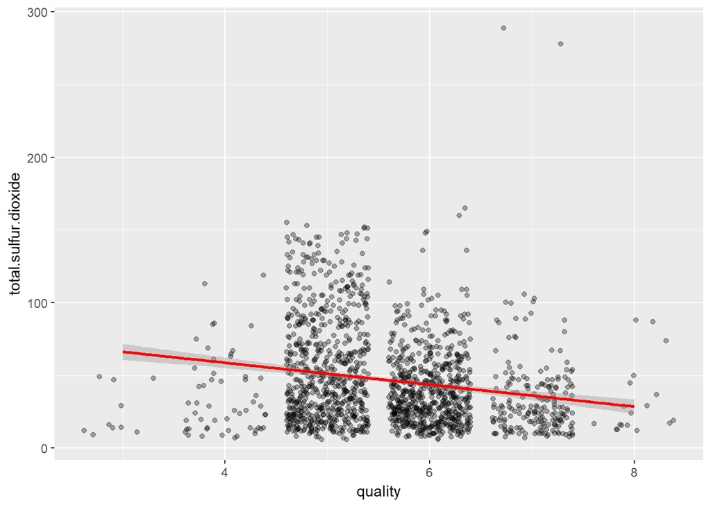

```
## # A tibble: 6 × 4
##   quality so2_mean so2_median     n
##     <int>    <dbl>      <dbl> <int>
## 1       3 24.90000       15.0    10
## 2       4 36.24528       26.0    53
## 3       5 56.51395       47.0   681
## 4       6 40.86991       35.0   638
## 5       7 35.02010       27.0   199
## 6       8 33.44444       21.5    18
```

The mean and median total.sulfur.dioxide increases till quality=5 and then shows a downward trend as quality increases. Hence, the negative correlation. The scatterplot, to a certain extent, shows that the best quality(=8) red wines have less total.sulfur.dioxide compared to the next best(=7).

```
##
##  Pearson's product-moment correlation
##
## data:  quality and sulphates
## t = 10.38, df = 1597, p-value < 2.2e-16
## alternative hypothesis: true correlation is not equal to 0
## 95 percent confidence interval:
##  0.2049011 0.2967610
## sample estimates:
##       cor
## 0.2513971
```

```
##
##  Pearson's product-moment correlation
##
## data:  quality and log10(sulphates)
## t = 12.967, df = 1597, p-value < 2.2e-16
## alternative hypothesis: true correlation is not equal to 0
## 95 percent confidence interval:
##  0.2636092 0.3523323
## sample estimates:
##       cor
## 0.3086419
```

For sulphates, I had log-transformed its values to create a normalised distribution during univariate analysis. The Pearsons correlation is more between quality and log-transformed sulphates which is 0.31, as compared to 0.25 (quality and sulphates).

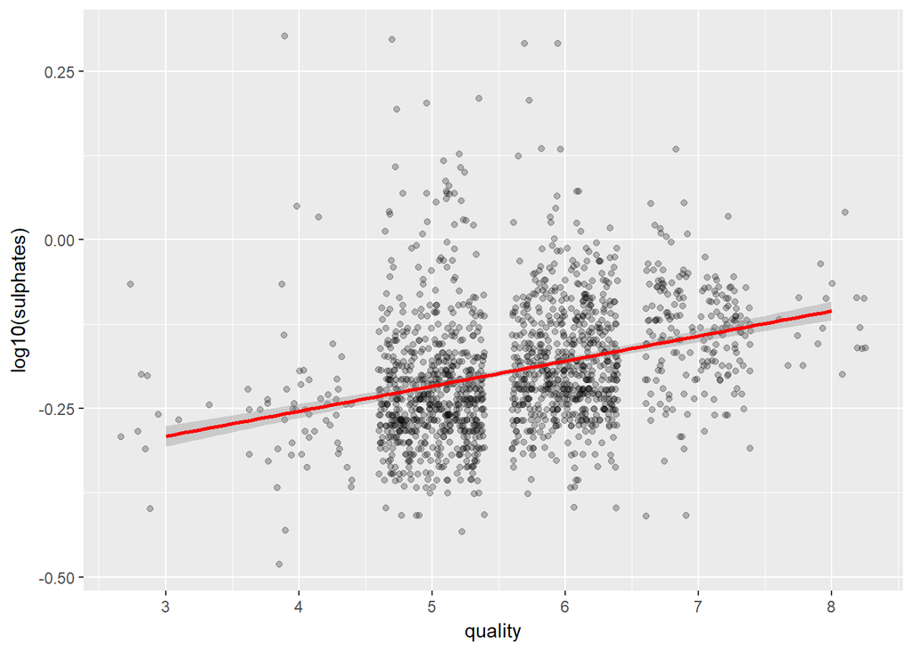

The above scatterplot between quality and log-transformed sulphates (smoothened using linear method) shows some correlation between sulphates and quality. In fact, the best red wines have higher sulphate levels compared to the mediocre and poor quality wines.

```
## # A tibble: 6 × 4
##   quality    s_mean s_median     n
##     <int>     <dbl>    <dbl> <int>
## 1       3 0.5700000    0.545    10
## 2       4 0.5964151    0.560    53
## 3       5 0.6209692    0.580   681
## 4       6 0.6753292    0.640   638
## 5       7 0.7412563    0.740   199
## 6       8 0.7677778    0.740    18
```

The above summary table (mean and median values of sulphates against quality) shows that sulphate levels increase with increasing quality and the median value of 0.74 seems to be optimum for the highest quality wines in our dataset.

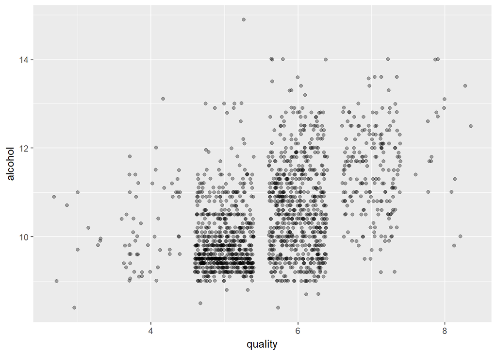

Based on the above scatterplot (alpha=1/3) between quality and alcohol content, I can say that the highest quality wines of our dataset have an alcohol content of more than 10%. Wines with higher alcohol levels, like greater than 13%, are mostly rated 6 or above.

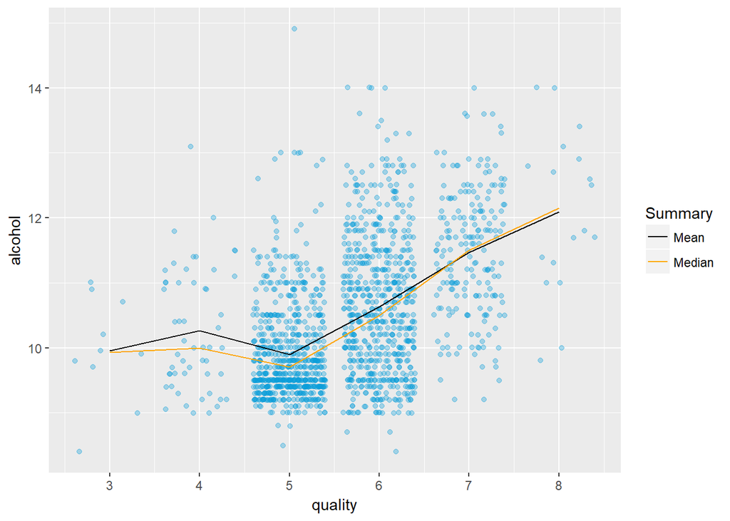

From the above plot, I can see that the mean and median values of alcohol just shoots up from levels below 10% to more than 12% as quality improves from 5 to 8. Let’s find the Pearson’s correlation coefficient between these two variables and take a closer look at the data on which the above plot is based.

```
##
##  Pearson's product-moment correlation
##
## data:  quality and alcohol
## t = 21.639, df = 1597, p-value < 2.2e-16
## alternative hypothesis: true correlation is not equal to 0
## 95 percent confidence interval:
##  0.4373540 0.5132081
## sample estimates:
##       cor
## 0.4761663
```

```
## # A tibble: 6 × 4
##   quality    a_mean a_median     n
##     <int>     <dbl>    <dbl> <int>
## 1       3  9.955000    9.925    10
## 2       4 10.265094   10.000    53
## 3       5  9.899706    9.700   681
## 4       6 10.629519   10.500   638
## 5       7 11.465913   11.500   199
## 6       8 12.094444   12.150    18
```

A correlation of 0.47 is moderately high and the highest among all the input variables of our dataset. In a way, alcohol has probably the highest impact on quality of red wines. Now when I look at the summary table of mean and median values of alcohol, I can see that wine experts would probably prefer red wines with alcohol content above 11%, to say the least.

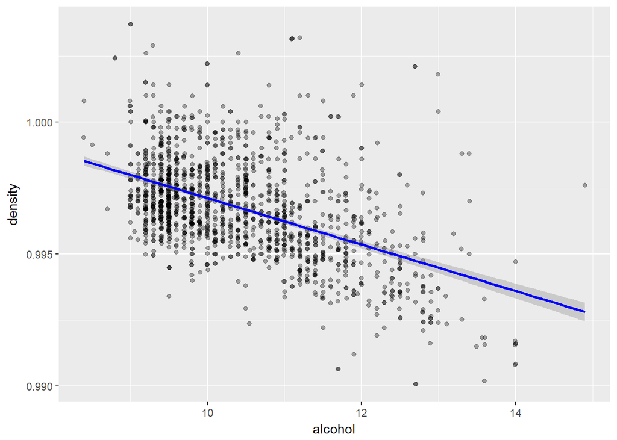

```
##
##  Pearson's product-moment correlation
##
## data:  alcohol and density
## t = -22.838, df = 1597, p-value < 2.2e-16
## alternative hypothesis: true correlation is not equal to 0
## 95 percent confidence interval:
##  -0.5322547 -0.4583061
## sample estimates:
##        cor
## -0.4961798
```

Alcohol content has an inverse relationship with density (correlation ~ -0.5). Some of the least dense wines (density <= 0.9925) have greater than 11% alcohol content, which is greater than both the mean and median values of alcohol. The relationship looks moderately linear.

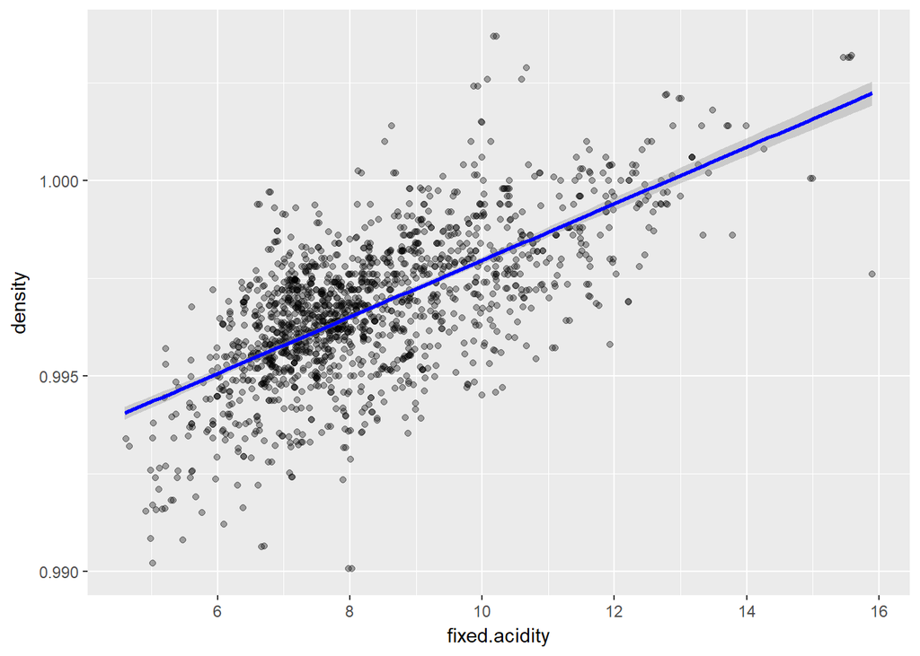

```
##
##  Pearson's product-moment correlation
##
## data:  fixed.acidity and density
## t = 35.877, df = 1597, p-value < 2.2e-16
## alternative hypothesis: true correlation is not equal to 0
## 95 percent confidence interval:
##  0.6399847 0.6943302
## sample estimates:
##       cor
## 0.6680473
```

Summary of fixed.acidity:

```
##    Min. 1st Qu.  Median    Mean 3rd Qu.    Max.
##    4.60    7.10    7.90    8.32    9.20   15.90
```

Fixed acidity has a high correlation with density (correlation ~ 0.67). In fact, for fixed.acidity between 6 and 10, the linear smooth seems to be a very good fit.

## Bivariate Analysis

### Talk about some of the relationships you observed in this part of the investigation. How did the feature(s) of interest vary with other features in the dataset?

Quality of red wines is moderately correlated with alcohol and volatile.acidity.

As alcohol content increases, quality of a red wine increases. Based on the scatterplot between alcohol and quality, I found that the mean and median values of alcohol just shoots up from levels below 10% to more than 12% as quality improves from 5 to 8. Based on the summary table of mean and median values of alcohol, I can see that wine experts preferred red wines with alcohol content above 11%.

On the other hand, volatile.acidity has an inverse relationship with quality. As volatile acidity decreases, quality of red wine increases. However, there is a slight increase in mean volatile.acidity right after quality=7 (8 being the highest in this dataset). However, the median volatile.acidity remains constant (0.37) for the highest quality wines.

Contrary to what I had earlier assumed, there isn’t much of a correlation between fixed.acidity and quality. However, citric.acid (*known to add ‘freshness’ and flavor to wines*) showed some correlation with quality. In fact, its mean and median summaries peaked for the best red wines. A citric.acid content of 0.4 g/dm<sup>3</sup> seems to be ideal for a good red wine.

On analysing the impact of chlorides on quality, I didn’t see much of a correlation, except for the fact that better quality red wines have low chloride levels. This, in a way, supports my assumption that higher amounts of salt imparted by chlorides is undesirable in wine. The relationship between total.sulfur.dioxide and quality is similar to chlorides.

Sulphates data, after being log-transformed, recorded a slight increase in its correlation with quality. Based on my analysis, sulphate levels increase with increasing quality and its median value of 0.74 seems to be optimum for the best red wines.

Very surprisingly, I did not find any impact of residual.sugar on quality. Most wines, irrespective of quality, have lower levels of residual.sugar. The higher levels, which is greater than 8 are mostly outliers.

### Did you observe any interesting relationships between the other features (not the main feature(s) of interest)?

Alcohol content has an inverse relationship with density (correlation ~ -0.5). Whereas, fixed.acidity has a high correlation with density (correlation ~ 0.67).

### What was the strongest relationship you found?

Among all the features, alcohol seems to have the strongest impact on the quality of a red wine. It has a positive and a moderately high correlation with quality. Sulphates and citric acid are the next in line to be positively correlated with quality, but less as compared to alcohol. On the other hand, quality is negatively and moderately correlated with volatile.acidity. Chlorides, too, has a negative, but a weak correlation with quality.

## Multivariate Plots Section

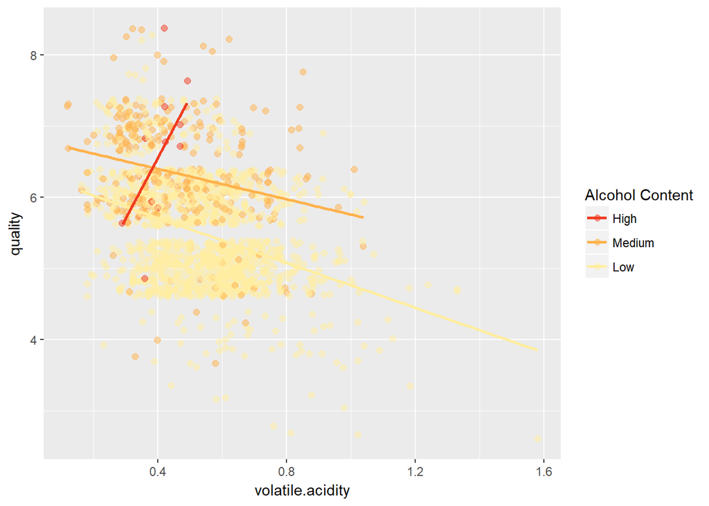

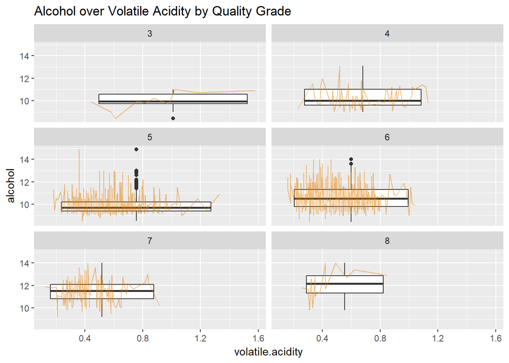

The second plot shows boxplots and line plots of alcohol over volatile.acidity faceted over each quality grade. Some of the lowest quality(=3) wines have the lowest levels of alcohol and highest levels of volatile.acidity. Most of the red wines graded highest (7 and 8) on quality have a median alcohol of around 12% and a volatile.acidity of around 0.5. Another thing I notice for these wines is that there are no outliers and therefore their patterns and trends tend to be less affected compared to the other quality wines.

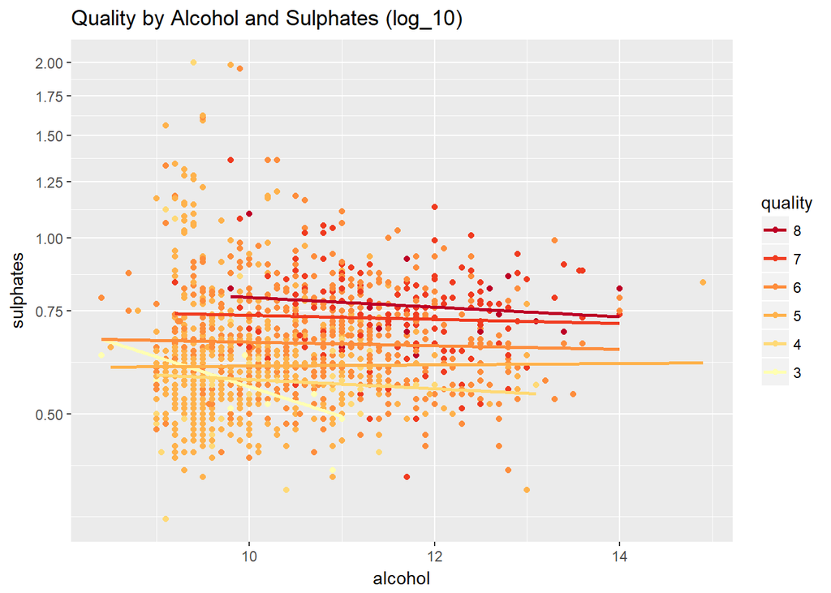

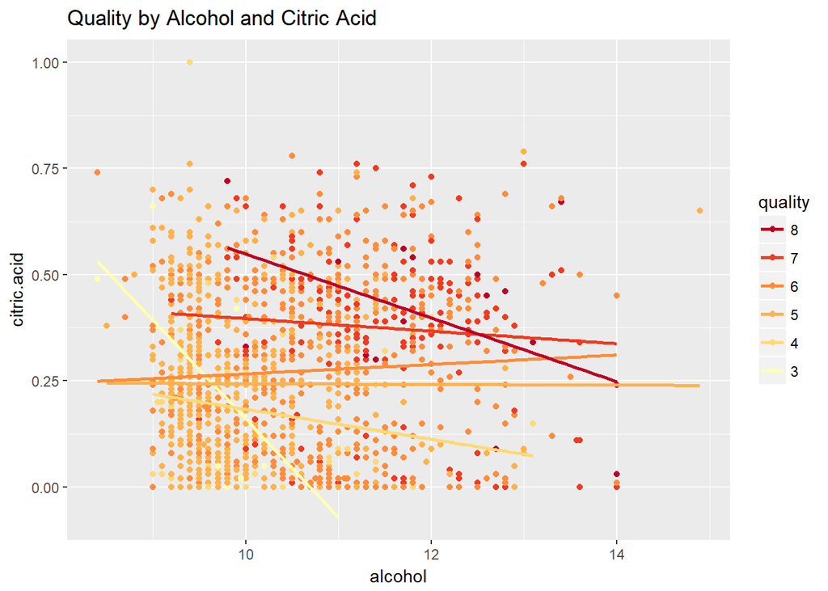

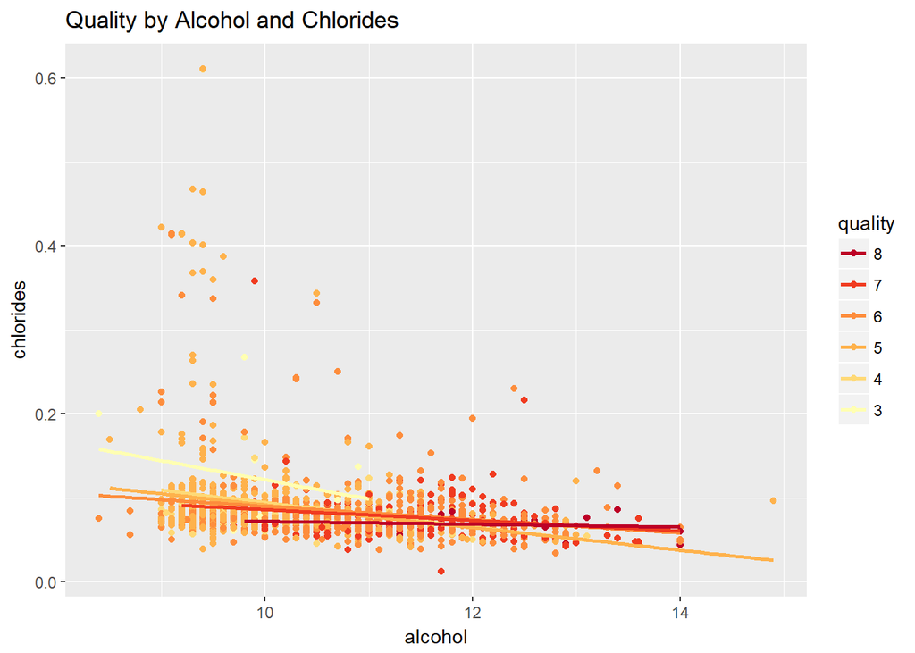

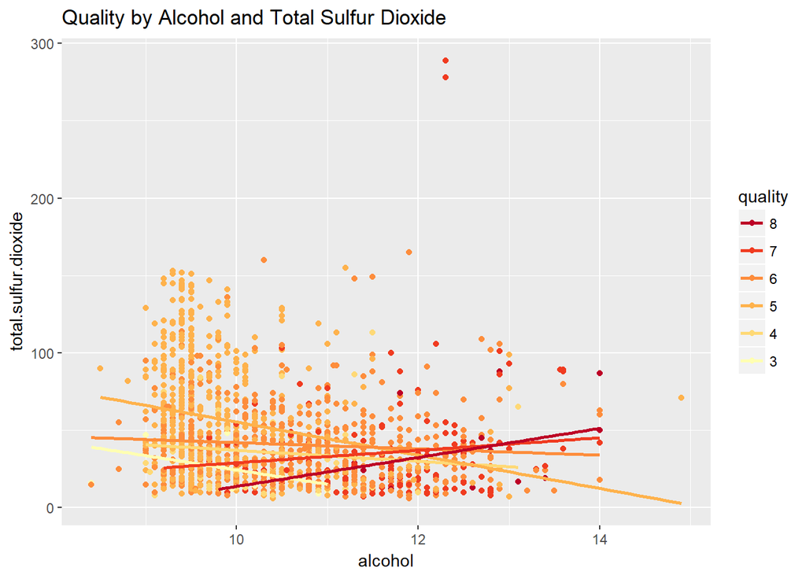

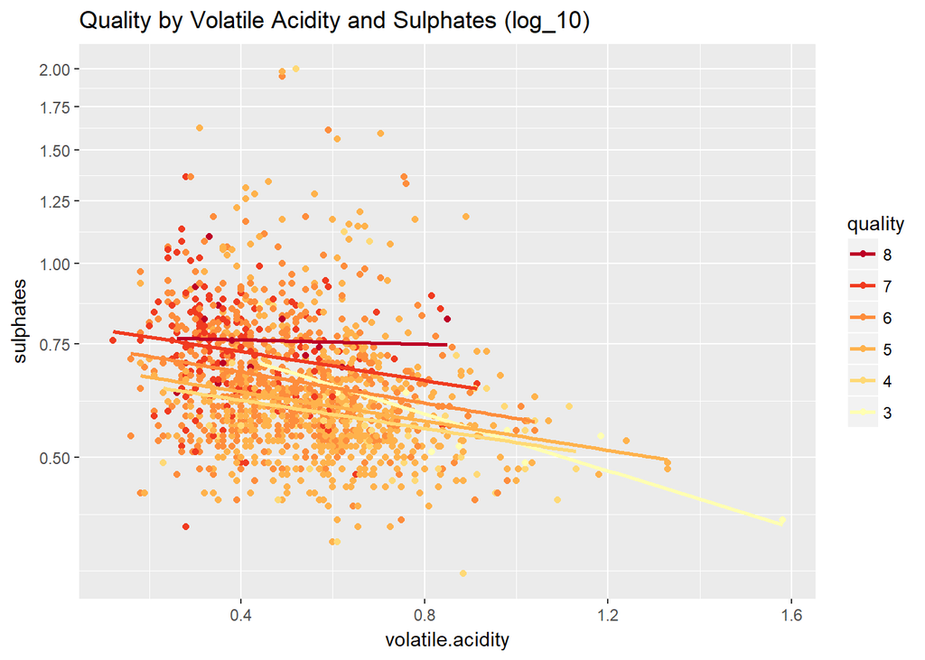

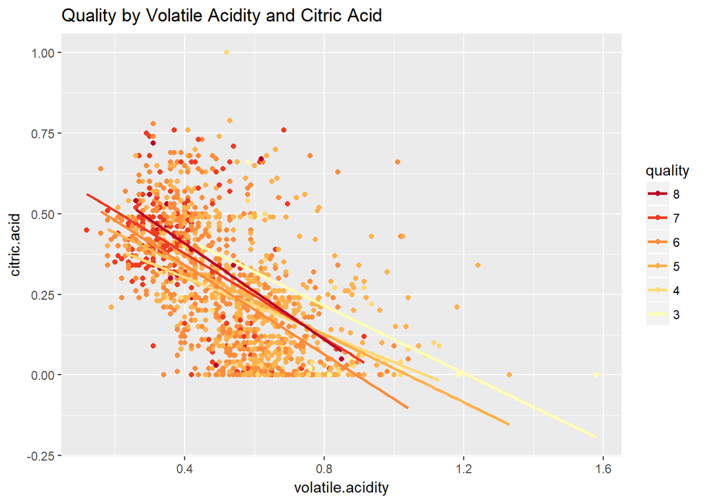

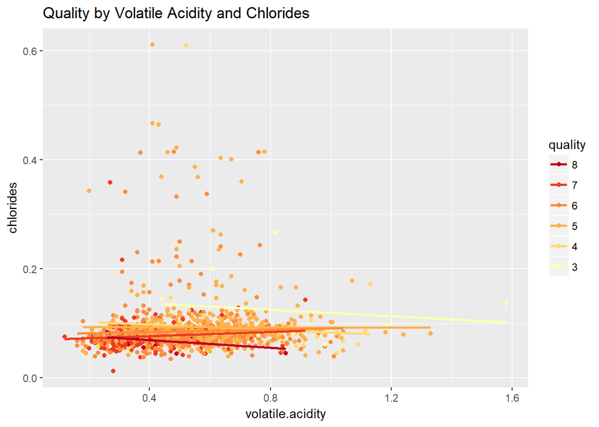

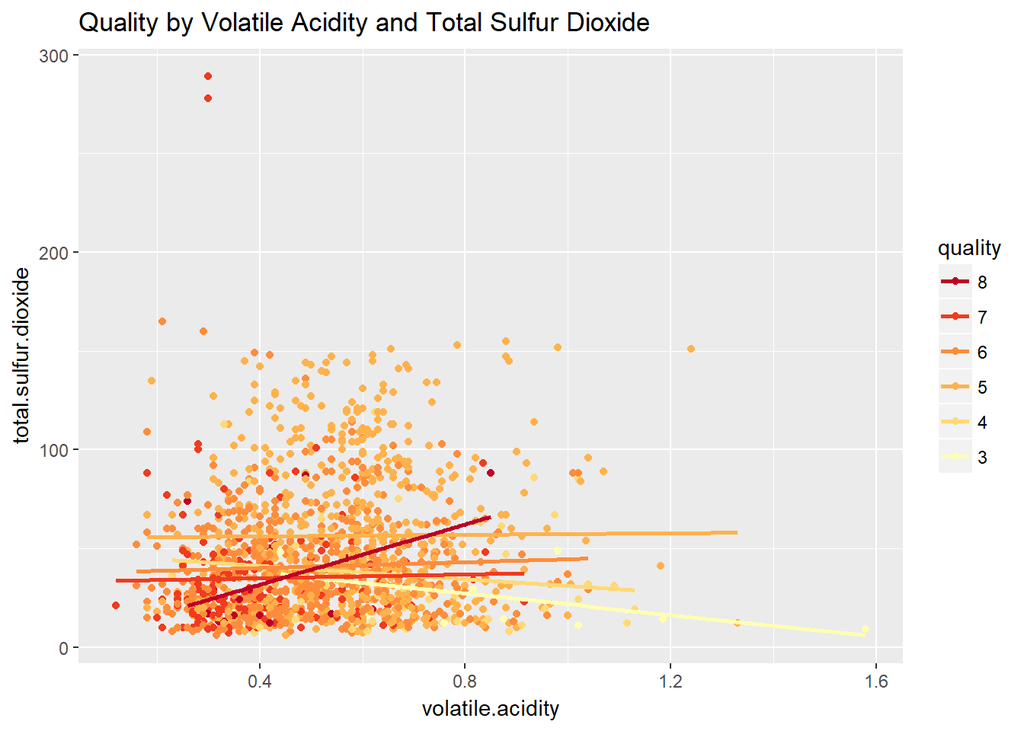

Here, too, sulphates and citric acid seem to have some positive effect on quality. This time, I see that red wines with lower level of chlorides and total.sulfur.dioxide have a better quality.

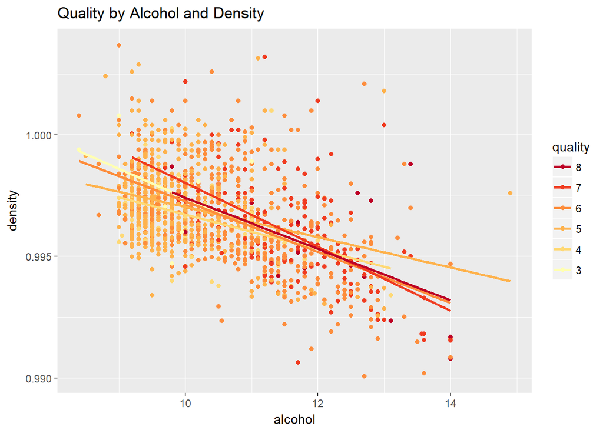

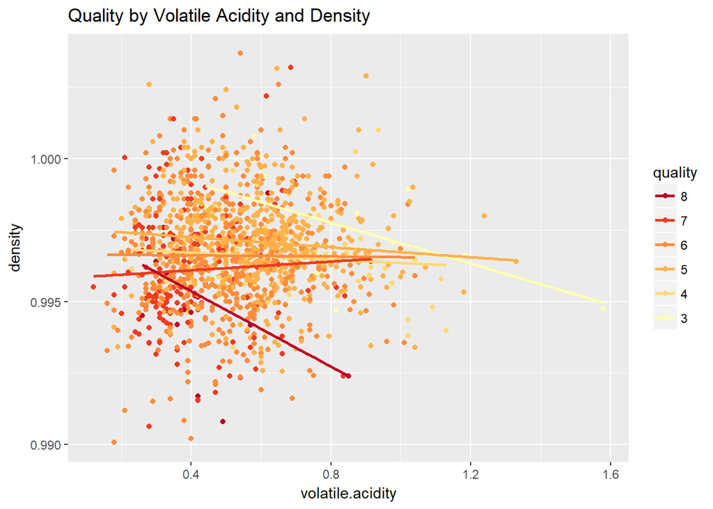

Effect of density on quality is not visible in the alcohol plot. However, when plotted with volatile.acidity, I see that a lot of better-quality wines are less dense compared to poor-quality wines.

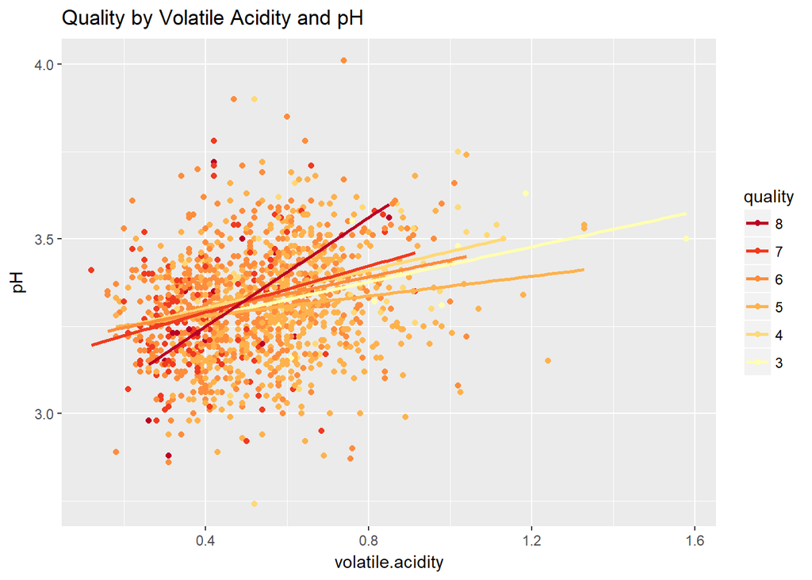

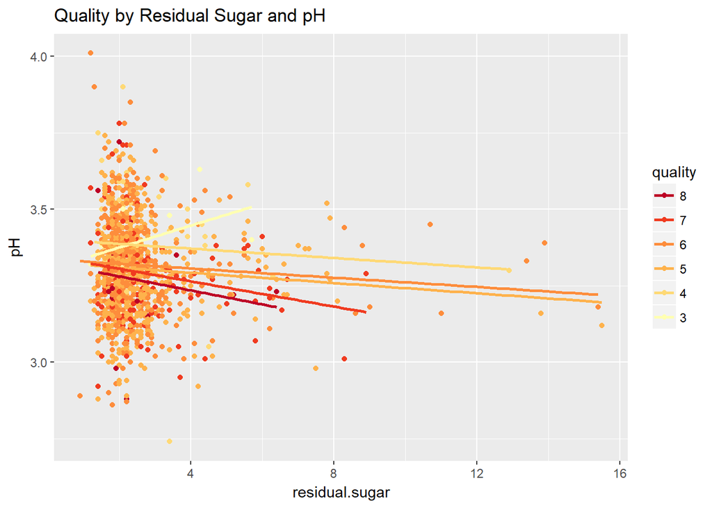

Again, volatile.acidity is showing positive correlation with pH which is quite the opposite of the expected relationship between pH and acidity. Residual sugar and pH doesn’t seem to be correlated, though.

From the first plot, most of the wines with lower volatile.acidity expected to be graded good in quality, shows a decrease of quality with increase of pH. The second plot furthers this argument by showing an increase in pH with decrease in wine quality. So, I can say that the better-quality wines have an inverse relationship with pH.

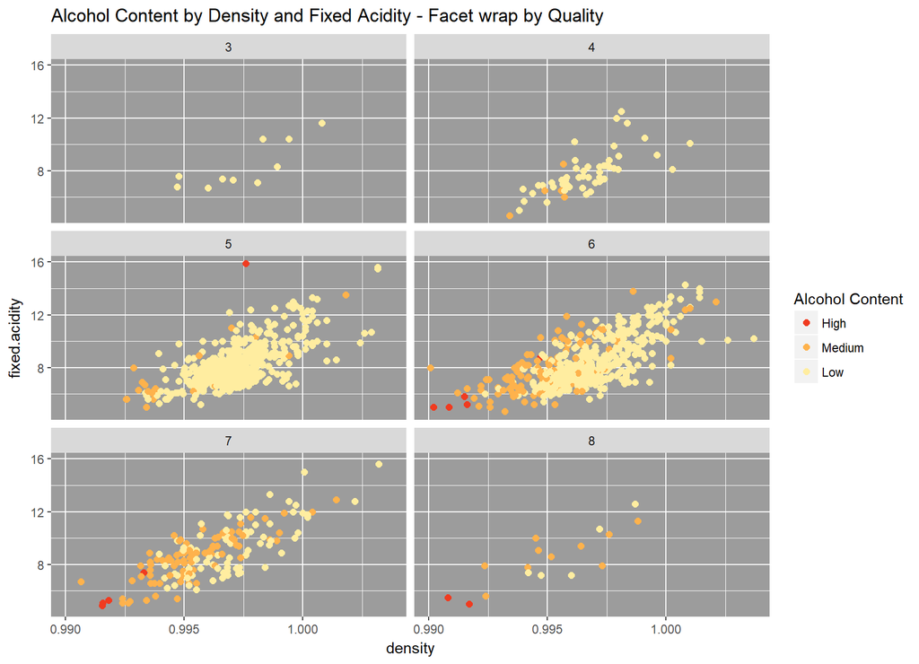

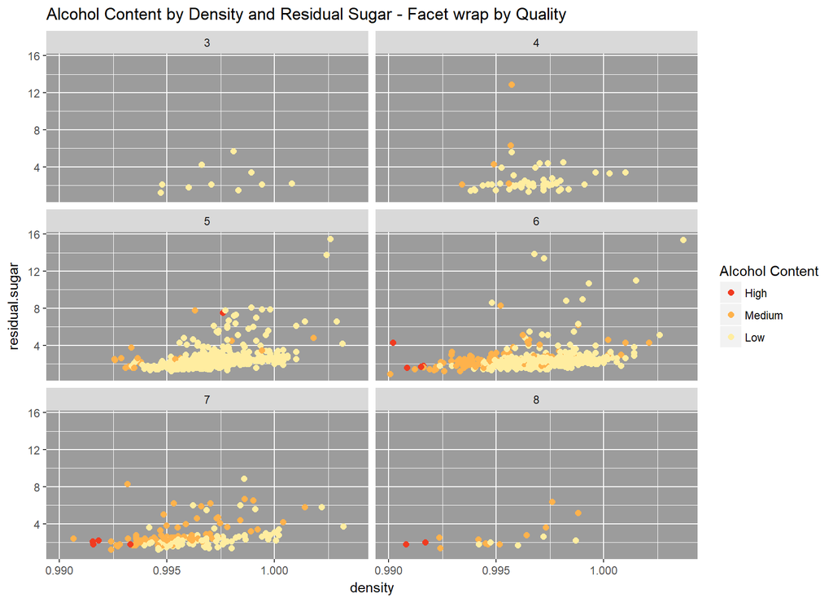

Density is highly correlated with fixed.acidity (positively) as well as alcohol (negatively). Coming to quality, fixed.acidity doesn’t seem to have much of an effect. Though, high-quality wines seem to be less dense, there are lower quality wines exhibiting the same. Similarly, residual sugar, too, does not affect quality in any considerable way.

```
##
## Calls:
## m1: lm(formula = I(quality) ~ I(alcohol), data = redwines)
## m2: lm(formula = I(quality) ~ I(alcohol) + volatile.acidity, data = redwines)
## m3: lm(formula = I(quality) ~ I(alcohol) + volatile.acidity + log10(sulphates),
##     data = redwines)
## m4: lm(formula = I(quality) ~ I(alcohol) + volatile.acidity + log10(sulphates) +
##     total.sulfur.dioxide, data = redwines)
## m5: lm(formula = I(quality) ~ I(alcohol) + volatile.acidity + log10(sulphates) +
##     total.sulfur.dioxide + chlorides, data = redwines)
## m6: lm(formula = I(quality) ~ I(alcohol) + volatile.acidity + log10(sulphates) +
##     total.sulfur.dioxide + chlorides + pH, data = redwines)
## m7: lm(formula = I(quality) ~ I(alcohol) + volatile.acidity + log10(sulphates) +
##     total.sulfur.dioxide + chlorides + pH + citric.acid, data = redwines)
##
## =====================================================================================================
##                            m1         m2         m3         m4         m5         m6         m7
## -----------------------------------------------------------------------------------------------------
##   (Intercept)            1.875***   3.095***   3.369***   3.612***   3.998***   5.369***   5.819***
##                         (0.175)    (0.184)    (0.184)    (0.191)    (0.208)    (0.395)    (0.461)
##   I(alcohol)             0.361***   0.314***   0.303***   0.290***   0.270***   0.285***   0.290***
##                         (0.017)    (0.016)    (0.016)    (0.016)    (0.016)    (0.017)    (0.017)
##   volatile.acidity                 -1.384***  -1.156***  -1.134***  -1.076***  -0.960***  -1.061***
##                                    (0.095)    (0.097)    (0.097)    (0.097)    (0.101)    (0.114)
##   log10(sulphates)                             1.477***   1.519***   1.843***   1.825***   1.864***
##                                               (0.177)    (0.176)    (0.189)    (0.189)    (0.190)
##   total.sulfur.dioxide                                   -0.002***  -0.002***  -0.002***  -0.002***
##                                                          (0.001)    (0.001)    (0.001)    (0.001)
##   chlorides                                                         -1.729***  -2.077***  -1.968***
##                                                                     (0.380)    (0.388)    (0.392)
##   pH                                                                           -0.468***  -0.590***
##                                                                                (0.115)    (0.132)
##   citric.acid                                                                             -0.226
##                                                                                           (0.120)
## -----------------------------------------------------------------------------------------------------
##   R-squared                 0.227      0.317      0.345      0.353      0.361      0.368      0.369
##   adj. R-squared            0.226      0.316      0.344      0.352      0.359      0.366      0.367
##   sigma                     0.710      0.668      0.654      0.650      0.646      0.643      0.643
##   F                       468.267    370.379    280.646    217.574    180.338    154.524    133.167
##   p                         0.000      0.000      0.000      0.000      0.000      0.000      0.000
##   Log-likelihood        -1721.057  -1621.814  -1587.752  -1578.324  -1568.023  -1559.722  -1557.943
##   Deviance                805.870    711.796    682.108    674.111    665.482    658.608    657.144
##   AIC                    3448.114   3251.628   3185.503   3168.648   3150.046   3135.443   3133.885
##   BIC                    3464.245   3273.136   3212.389   3200.911   3187.686   3178.460   3182.280
##   N                      1599       1599       1599       1599       1599       1599       1599
## =====================================================================================================
```

The variables in this linear model can account for 36.9% of the variance in the quality of red wines. With only alcohol and volatile acidity, we can account for 31.7% of the variance. However, with log transformation of sulphates, we can account for 34.5% of the variance.

## Multivariate Analysis

### Talk about some of the relationships you observed in this part of the investigation. Were there features that strengthened each other in terms of looking at your feature(s) of interest?

When plotted with volatile.acidity and residual.sugar, pH was found to be inversely related with the quality of wines.

### Were there any interesting or surprising interactions between features?

pH, which is expected to have an inverse relationship with acidic features, showed positive correlation with volatile acidity. Also, contrary to the seemingly popular belief that sugar can result in an increase in pH value, residual sugar showed absolutely no signs of correlation with pH.

### OPTIONAL: Did you create any models with your dataset? Discuss the strengths and limitations of your model.

Yes, I created a linear model starting from alcohol and volatile acidity.

# Final Plots and Summary

### Plot One

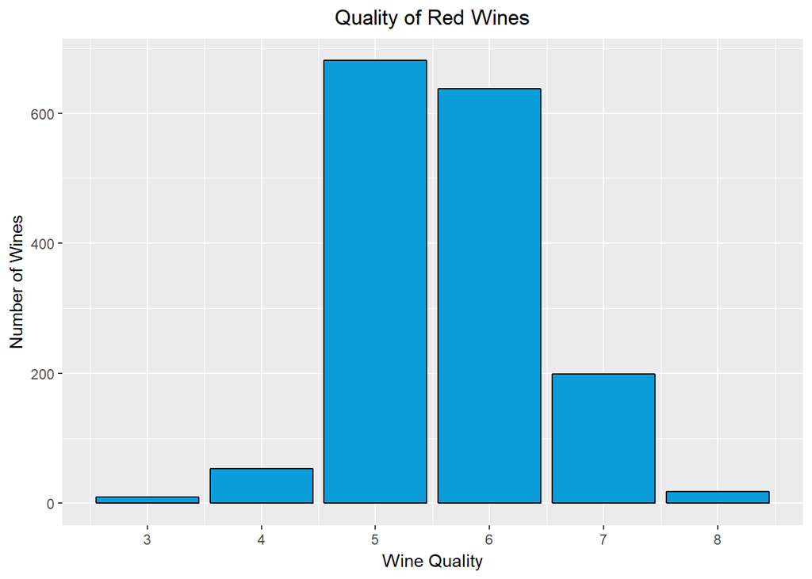

Count of wines by Quality (3 to 8):

```
##
##   3   4   5   6   7   8
##  10  53 681 638 199  18
```

### Description One

The distribution of quality of red wines appears to be a normal distribution, peaking at quality equal to 5 and 6. Additionally, the table below the histogram tells us that more than 80% of the wine samples were graded average by experts.

### Plot Two

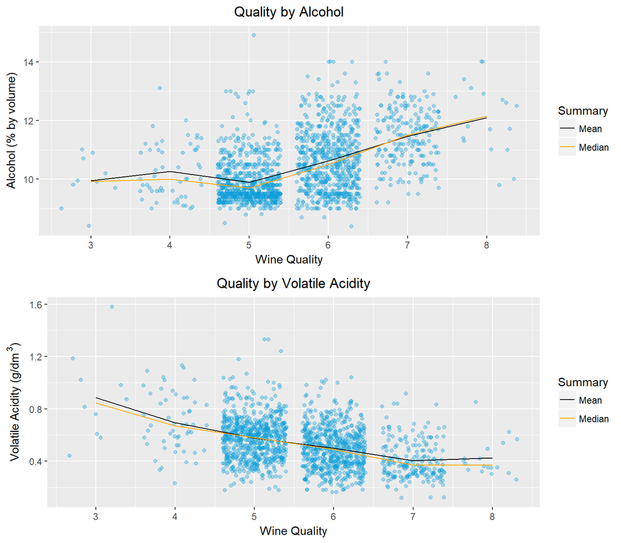

### Description Two

The mean and median values of alcohol just shoots up from levels below 10% to more than 12% as quality improves from 5 to 8. On the other hand, volatile acidity decreases as quality of wine increases. From the mean and median summaries of volatile acidity, it looks like the best quality wines have a volatile acidity of around 0.4 g/dm<sup>3</sup>.

### Plot Three

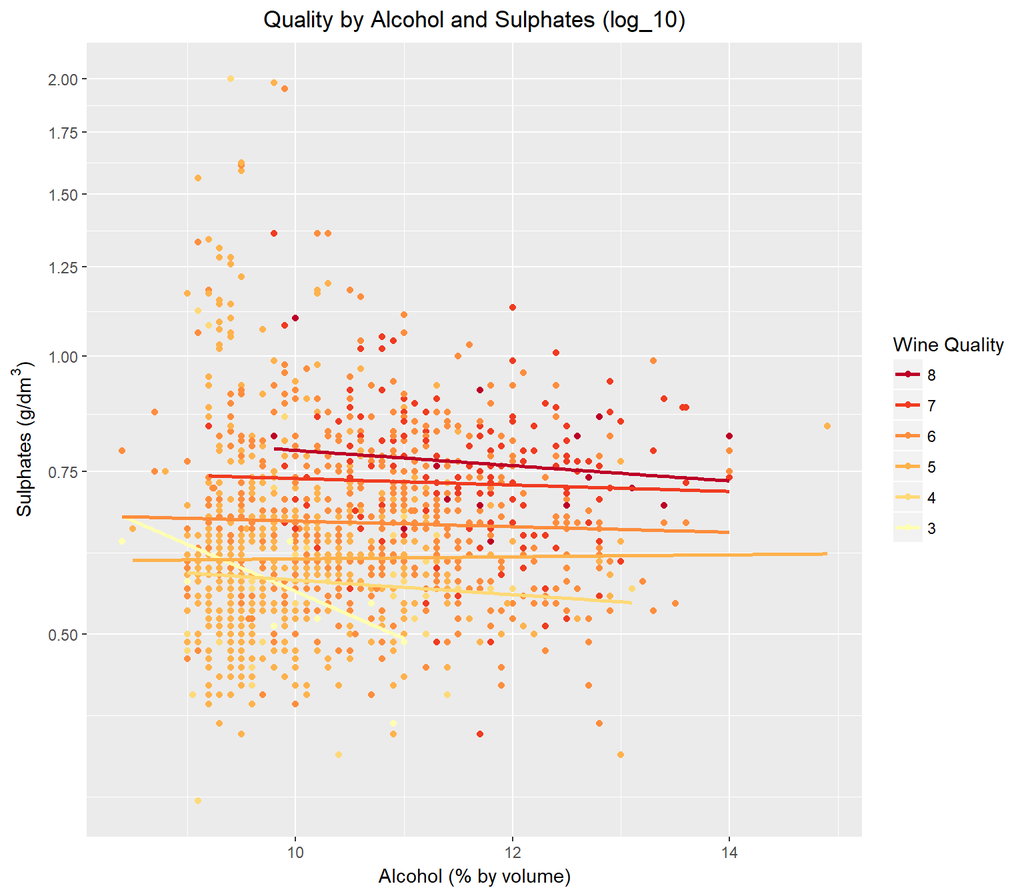

### Description Three

After having determined that alcohol content and volatile acidity have some effect on the quality of red wine, sulphates was the next feature to have maximum correlation with quality. Log-transformation of sulphates led to more correlaton and resulted in a more normalised distribution. This plot shows that keeping alcohol constant, the yellow dots slowly turn to orange and then to red with increasing value of sulphates. So, higher level of sulphates do have a positive effect on quality

# Reflection

The red wines data set contains 1599 instances of red wine and its 12 attributes. Out of these 12 attributes, eleven are based on physiochemical tests and are termed as input variables. The twelfth attribute, “quality”, is scored between 0(very bad) and 10(excellent) based on sensory data and is termed as the output variable. I started by understanding the individual variables in the data set, and then I explored interesting questions and leads as I continued to make observations on plots. Eventually, I explored the quality of red wines across many variables and created a linear model that can account for 36.9% variance in the quality of red wines.

Out of all the input variables, alcohol and volatile acdity showed some degree of impact on the quality of a red wine. While higher alcohol content positively affected the wine quality, volatile acidity showed a negative correlation with the quality of red wines. I was surprised that fixed acidity and residual sugar (transformed or not), known to add tartness and dryness in wine taste, did not show any worthwhile correlation with quality. I categorised wines based on 3 levels of alcohol-content, which helped me further to establish these findings.

I also thought that chlorides and citric acid will show some substantial correlation with quality as their presence in wines is supposed to affect its taste considerably. Though both these features showed “some” impact, it was definitely less than what I had expected. What met my expectations though, was the fact that chlorides, known to add an undesirable salty taste to wines, was negatively correlated. Whereas, citric acid, which can add freshness and flavor to wines showed a positive correlation with wine quality, as expected.

Sulphates showed some correlation with quality which improved a bit after log-transformation. Keeping alcohol constant, I found higher levels of sulphates to have a positive effect on quality. Now, sulphates are known to add sulfur dioxide gas levels which, beyond certain concentraions, becomes evident in the nose and taste of wine. So, I naturally progressed to explore both “free” and “total” sulfur dioxide features expecting either or both of them to have a similar (i.e. positive) effect on quality. Though free sulfur dioxide has no effect, I was rather surprised to find that total sulfur dioxide has a negative correlation with quality. pH, too, showed an inverse relationship but, with better-quality wines having lower levels of volatile acidity.

At the end, I created a linear model using 7 (*i.e. alcohol, volatile.acidity, sulphates, total.sulfur.dioxide, chlorides, pH and citric acid*) of the 11 attributes that can account for 36.9% of the variance in the quality of red wines. This is pretty low as compared to what I would have preferred. However, I feel that this will improve if we have more records for lowest and highest quality wines that will evenly distribute the dataset across all the ratings. This current dataset has more than 80% of the wine samples graded as average (i.e. rated 5 or 6) whereas the remaining 20% are distributed among the other 4 ratings. Also, information regarding grape types, wine brand, wine selling price (*currently unavailable due to privacy and logistic issues*) may account for better results in predicting the quality of red wines.